# Predictive Text App

## A shiny application

James Kennedy

## Introduction

This presentation looks at the predictive text application created for the JHU Data Science Capstone project.  
It discusses:

- The natural language processing (NLP)
- The data, data processing and predictive text model used in this Capstone project
- The predictive text shiny app

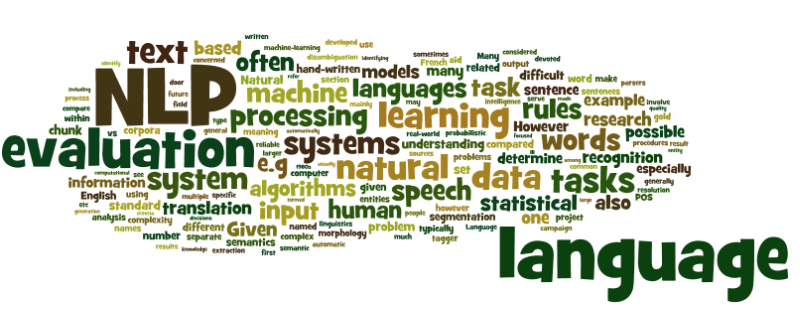

## What is Natural Language Processing?

Natural Language Processing looks at the ways computers and human language can interact. Its uses include:

- Automatically summarizing documents.
- Automatically translating documents or speech from one language to another
- Predicting upcoming or missing text.

### Question:

What text do you think follows the text "I do not like ..."?

1. green eggs and ham.
2. them, Sam-I-am.
3. *Both*

This example is taken from Dr. Seuss' Green Eggs and Ham story.

Both examples appear in the story 'Green Eggs and Ham', so both can possibly follow the text. NLP and modelling techniques aim to select which of the potential answers is most probable!

## The Backoff algorithm

This application uses a back-off algorithm to estimate a word of text given the preceding text. This algorithm uses a body of text, or corpus, to generate groups of single, pairs, or larger groups of words called n-grams, where n refers to the number of words in the group.  
For Example:

- 1-grams: I, you, the, cat, dog
- 2-grams: I am, You are, The car, The cat, A dog
- 3-grams: I am hungry, You are pretty, The car has, The cat jumps, A dog barks

When a phrase is given, the algorithm searches for matches in the highest-level n-gram. The most frequent word from the resulting matches is predicted to follow the text. If no matches are found, the algorithm 'backs off' to a lower-level n-gram and repeats the search. If no matches are found in any n-gram, the most frequent word in the corpus is given as predicted text.

## The Predictive Text App

The [Predictive Text App](https://kennej3.shinyapps.io/TextApp/) is a web application that uses the back-off method to predict the proceeding word given an input phrase. The application uses the data and processing described in the milestone report presented [here](https://rpubs.com/kennej3/137918) with the following changes:

- Taking the advice of the report reviewers, the stemDocument function is no longer used.
- A 4-gram has been created and is used along with the 3,2,and 1-grams.
- To save memory and prevent over-weighting rare n-grams, only grams which occur more than 5 times are saved/used.

The Rmarkdown files used in the data processing and predictive text functions are available on github at github.com/kennej3/predictive-text-app

Please visit the Predictive Text shiny app at https://kennej3.shinyapps.io/TextApp today!